# Lesson 7: Tabular Data

## Pt 1

### Decision Tree Ensembles

Some examples include... - Random Forest (Regressor / Classifier) - Gradient Boost (Regressor / Classifier) - XGBoost (Regressor / Classifier)

We will use the [Scikit-Learn](https://scikit-learn.org/stable/) library for this task rather than PyTorch.

### The Data

- Blue Book for Bulldozers Kaggle Competition
- The goal being to predict sale price of heavy equipment at auction based on ussage, type and configuration.

### Kaggle setup help

There are a number of different ways to do this, I had some trouble doing [this](https://gist.github.com/ksferguson/0b384e892689617d1539d35c1254eb01) so after some reading, tried [this](https://forums.fast.ai/t/kaggle-json/70088/7) instead.

### fastai helper functions

- Had some trouble importing fastais helper functions, found that someone has added them all [here](https://lewtun.github.io/dslectures/structured/)

```
from pathlib import Path

from pandas.api.types import is_string_dtype, is_numeric_dtype, is_categorical_dtype

from fastai.tabular.all import *
# helper functions
from fastbook import *

from sklearn.ensemble import RandomForestRegressor
from sklearn.tree import DecisionTreeRegressor,export_graphviz

from dtreeviz.trees import *

import IPython
from IPython.display import Image, display_svg, SVG

import os
```

**Load credentials** from json file. This is a simple file with the following information...

```
{"username":"xxx","key":"xxx"}
```

```
import json

with open('creds.json') as f:
    creds = json.load(f)
```

```
os.environ['KAGGLE_USERNAME']=creds["username"]
os.environ['KAGGLE_KEY']=creds["key"]
```

```
from kaggle import api

api.competition_download_cli('bluebook-for-bulldozers')
```

```
Downloading bluebook-for-bulldozers.zip to /notebooks
```

```
p = Path.cwd()

for i in p.iterdir():
    print(i)
```

```
/notebooks/.ipynb_checkpoints
/notebooks/.kaggle
/notebooks/course-v4
/notebooks/fastbook
/notebooks/lesson1_assets
/notebooks/models
/notebooks/20200920_fastai_lesson_prod_app.ipynb
/notebooks/20201006_fastai_lesson_6.ipynb
/notebooks/20201026_fastai_lesson_6_collab.ipynb
/notebooks/bluebook-for-bulldozers.zip
/notebooks/lesson_7_tabular.ipynb
/notebooks/storage
/notebooks/datasets
```

```
fname = p/'bluebook-for-bulldozers.zip'

dest = p/'storage/data/bluebook'
# dest.mkdir()

# only run once!
#file_extract(fname, dest)
```

### The Data

each row of the dataset represents the sale of a single machine at an auction

```
df = pd.read_csv(dest/'TrainAndValid.csv', low_memory=False)

df.head()
```

|  | SalesID | SalePrice | MachineID | ModelID | datasource | auctioneerID | YearMade | MachineHoursCurrentMeter | UsageBand | saledate | ... | Undercarriage_Pad_Width | Stick_Length | Thumb | Pattern_Changer | Grouser_Type | Backhoe_Mounting | Blade_Type | Travel_Controls | Differential_Type | Steering_Controls |
| --- | --- | --- | --- | --- | --- | --- | --- | --- | --- | --- | --- | --- | --- | --- | --- | --- | --- | --- | --- | --- | --- |
| 0 | 1139246 | 66000.0 | 999089 | 3157 | 121 | 3.0 | 2004 | 68.0 | Low | 11/16/2006 0:00 | ... | NaN | NaN | NaN | NaN | NaN | NaN | NaN | NaN | Standard | Conventional |
| 1 | 1139248 | 57000.0 | 117657 | 77 | 121 | 3.0 | 1996 | 4640.0 | Low | 3/26/2004 0:00 | ... | NaN | NaN | NaN | NaN | NaN | NaN | NaN | NaN | Standard | Conventional |
| 2 | 1139249 | 10000.0 | 434808 | 7009 | 121 | 3.0 | 2001 | 2838.0 | High | 2/26/2004 0:00 | ... | NaN | NaN | NaN | NaN | NaN | NaN | NaN | NaN | NaN | NaN |
| 3 | 1139251 | 38500.0 | 1026470 | 332 | 121 | 3.0 | 2001 | 3486.0 | High | 5/19/2011 0:00 | ... | NaN | NaN | NaN | NaN | NaN | NaN | NaN | NaN | NaN | NaN |
| 4 | 1139253 | 11000.0 | 1057373 | 17311 | 121 | 3.0 | 2007 | 722.0 | Medium | 7/23/2009 0:00 | ... | NaN | NaN | NaN | NaN | NaN | NaN | NaN | NaN | NaN | NaN |

5 rows × 53 columns

```
df.columns
```

```
Index(['SalesID', 'SalePrice', 'MachineID', 'ModelID', 'datasource',
       'auctioneerID', 'YearMade', 'MachineHoursCurrentMeter', 'UsageBand',
       'saledate', 'fiModelDesc', 'fiBaseModel', 'fiSecondaryDesc',
       'fiModelSeries', 'fiModelDescriptor', 'ProductSize',
       'fiProductClassDesc', 'state', 'ProductGroup', 'ProductGroupDesc',
       'Drive_System', 'Enclosure', 'Forks', 'Pad_Type', 'Ride_Control',
       'Stick', 'Transmission', 'Turbocharged', 'Blade_Extension',
       'Blade_Width', 'Enclosure_Type', 'Engine_Horsepower', 'Hydraulics',
       'Pushblock', 'Ripper', 'Scarifier', 'Tip_Control', 'Tire_Size',
       'Coupler', 'Coupler_System', 'Grouser_Tracks', 'Hydraulics_Flow',
       'Track_Type', 'Undercarriage_Pad_Width', 'Stick_Length', 'Thumb',
       'Pattern_Changer', 'Grouser_Type', 'Backhoe_Mounting', 'Blade_Type',
       'Travel_Controls', 'Differential_Type', 'Steering_Controls'],
      dtype='object')
```

### Transforming data

- convert categorical ie `ProductSize`
- set order

```
df['ProductSize'].unique()
```

```
array([nan, 'Medium', 'Small', 'Large / Medium', 'Mini', 'Large',
       'Compact'], dtype=object)
```

```
sizes = 'Large','Large / Medium','Medium','Small','Mini','Compact'
```

```
df['ProductSize'] = df['ProductSize'].astype('category')
df['ProductSize'].cat.set_categories(sizes, ordered=True, inplace=True)
```

dependent variable here is `SalePrice`, this is the variable we want to predict. Kaggle specifically tells us the metric to use: root mean squared log error (RMSLE). To use this metric, we need to take the log of the dependent variable which will allow use to use RMSE

```
dep_var = 'SalePrice'
```

```
df[dep_var] = np.log(df[dep_var])
```

### Decision Trees

- ask binary questions about data
  - ie is x > y
- the trouble is we don't know what binary questions to ask, and through machine learning, we need to decide on what these will be.

### Handling Dates

```
df = add_datepart(df, 'saledate')
df_test = pd.read_csv(dest/'Test.csv', low_memory=False)
df_test = add_datepart(df_test, 'saledate')
```

### Using TabularPandas and TabularProc

we will use two tabular transforms to modify our data. - Categorify - replaces a column with numeric category - FillMissign - fills any missing data with the median - also adds a boolean column where `True` will be set for any data point that was missing

```
procs = [Categorify, FillMissing]
```

**Validation Set**

hold aside some data (approx 2 weeks) as per the competition rules - do this with `np.where`

```
cond = (df.saleYear<2011) | (df.saleMonth<10)

train_idx = np.where(cond)[0]
valid_idx = np.where(~cond)[0] # inverse condition

splits = (list(train_idx), list(valid_idx))
```

Here `cont_cat_split` is a helper function that returns column names of cont and cat variables from given `df`.

```
# define continuous and categorical columns for TabularPandas

cont,cat = cont_cat_split(df, 1, dep_var=dep_var)
```

### create a Tabular Object (to)

```
to = TabularPandas(df, procs, cat, cont, y_names=dep_var, splits=splits)
```

```
len(to.train), len(to.valid)
```

```
(404710, 7988)
```

Look at the data with `to.show`. This will show the data in human readable form. `to.items.head` will show the processed data in numerical form.

```
to.show(3)
```

|  | UsageBand | fiModelDesc | fiBaseModel | fiSecondaryDesc | fiModelSeries | fiModelDescriptor | ProductSize | fiProductClassDesc | state | ProductGroup | ProductGroupDesc | Drive_System | Enclosure | Forks | Pad_Type | Ride_Control | Stick | Transmission | Turbocharged | Blade_Extension | Blade_Width | Enclosure_Type | Engine_Horsepower | Hydraulics | Pushblock | Ripper | Scarifier | Tip_Control | Tire_Size | … |
| --- | --- | --- | --- | --- | --- | --- | --- | --- | --- | --- | --- | --- | --- | --- | --- | --- | --- | --- | --- | --- | --- | --- | --- | --- | --- | --- | --- | --- | --- | --- |
| 0 | Low | 521D | 521 | D | #na# | #na# | #na# | Wheel Loader - 110.0 to 120.0 Horsepower | Alabama | WL | Wheel Loader | #na# | EROPS w AC | None or Unspecified | #na# | None or Unspecified | #na# | #na# | #na# | #na# | #na# | #na# | #na# | 2 Valve | #na# | #na# | #na# | #na# | None or Unspecified | … |
| 1 | Low | 950FII | 950 | F | II | #na# | Medium | Wheel Loader - 150.0 to 175.0 Horsepower | North Carolina | WL | Wheel Loader | #na# | EROPS w AC | None or Unspecified | #na# | None or Unspecified | #na# | #na# | #na# | #na# | #na# | #na# | #na# | 2 Valve | #na# | #na# | #na# | #na# | 23.5 | … |
| 2 | High | 226 | 226 | #na# | #na# | #na# | #na# | Skid Steer Loader - 1351.0 to 1601.0 Lb Operating Capacity | New York | SSL | Skid Steer Loaders | #na# | OROPS | None or Unspecified | #na# | #na# | #na# | #na# | #na# | #na# | #na# | #na# | #na# | Auxiliary | #na# | #na# | #na# | #na# | #na# | … |

```
to.items.head(3)
```

|  | SalesID | SalePrice | MachineID | ModelID | datasource | auctioneerID | YearMade | MachineHoursCurrentMeter | UsageBand | fiModelDesc | ... | saleDayofyear | saleIs_month_end | saleIs_month_start | saleIs_quarter_end | saleIs_quarter_start | saleIs_year_end | saleIs_year_start | saleElapsed | auctioneerID_na | MachineHoursCurrentMeter_na |
| --- | --- | --- | --- | --- | --- | --- | --- | --- | --- | --- | --- | --- | --- | --- | --- | --- | --- | --- | --- | --- | --- |
| 0 | 1139246 | 11.097410 | 999089 | 3157 | 121 | 3.0 | 2004 | 68.0 | 2 | 963 | ... | 320 | 1 | 1 | 1 | 1 | 1 | 1 | 2647 | 1 | 1 |
| 1 | 1139248 | 10.950807 | 117657 | 77 | 121 | 3.0 | 1996 | 4640.0 | 2 | 1745 | ... | 86 | 1 | 1 | 1 | 1 | 1 | 1 | 2148 | 1 | 1 |
| 2 | 1139249 | 9.210340 | 434808 | 7009 | 121 | 3.0 | 2001 | 2838.0 | 1 | 336 | ... | 57 | 1 | 1 | 1 | 1 | 1 | 1 | 2131 | 1 | 1 |

3 rows × 67 columns

check the vocab with `to.classes`

```
to.classes['ProductSize']
```

```
(#7) ['#na#','Large','Large / Medium','Medium','Small','Mini','Compact']
```

```
# save the tabular object for later

# (dest/'to.pkl').save(to)
```

## Decision Tree Regressor: for continuous variables

```
# had to copy from
# https://github.com/anandsaha/fastai.part1.v2/blob/master/fastai/structured.py

def draw_tree(t, df, size=10, ratio=0.6, precision=0):
    """ Draws a representation of a random forest in IPython.
    Parameters:
    -----------
    t: The tree you wish to draw
    df: The data used to train the tree. This is used to get the names of the features.
    """
    s=export_graphviz(t, out_file=None, feature_names=df.columns, filled=True,
                      special_characters=True, rotate=True, precision=precision)
    IPython.display.display(graphviz.Source(re.sub('Tree {',
       f'Tree {{ size={size}; ratio={ratio}', s)))
```

```
xs,y = to.train.xs, to.train.y

valid_xs, valid_y = to.valid.xs, to.valid.y
```

```
m = DecisionTreeRegressor(max_leaf_nodes=4)
m.fit(xs, y);
```

```
draw_tree(m, xs, precision=2);
```

[figure not shown]

```
samp_idx = np.random.permutation(len(y))[:500]
dtreeviz(m, xs.iloc[samp_idx], y.iloc[samp_idx], xs.columns, dep_var,
        fontname='DejaVu Sans', scale=1.6, label_fontsize=10,
        orientation='LR')
```

[figure not shown]

Using Dtreeviz is a little more intuitive and provides a bit more information. For example, `YearMade` is showing that there are years equal to 1000, which is obviously an error in the data. Let's fix that

```
xs.loc[xs['YearMade']<1900, 'YearMade'] = 1950
valid_xs.loc[valid_xs['YearMade']<1900, 'YearMade'] = 1950
```

```
m = DecisionTreeRegressor(max_leaf_nodes=4).fit(xs, y)

dtreeviz(m, xs.iloc[samp_idx], y.iloc[samp_idx], xs.columns, dep_var,
        fontname='DejaVu Sans', scale=1.6, label_fontsize=10,
        orientation='LR')
```

[figure not shown]

```
# remove max_leaf_nodes
# build a bigger tree
m = DecisionTreeRegressor()
m.fit(xs, y)
```

```
DecisionTreeRegressor()
```

```
def r_mse(preds,y): return round(math.sqrt(((preds-y)**2).mean()),6)
def m_rmse(m, xs, y): return r_mse(m.predict(xs), y)
```

```
m_rmse(m, xs, y)
```

```
0.0
```

```
m_rmse(m, valid_xs, valid_y)
```

```
0.333069
```

Our training set is 0 and validation set is worse than the observed value from the original tree viz. The reason is that there are almost as many leaves in our model than observations in our data set. To avoid this, we need to pick some stopping criteria, like some threshold that will tell the model, don't split this if there are less than x number of items in the leaf node. Do this with `min_samples_leaf`.

```
m.get_n_leaves(), len(xs)
```

```
(324549, 404710)
```

we have nearly as many leaf nodes as observations in our dataset

we need to create some rules here

```
m = DecisionTreeRegressor(min_samples_leaf=25)
m.fit(to.train.xs, to.train.y)
m_rmse(m, xs, y), m_rmse(m, valid_xs, valid_y)
```

```
(0.248593, 0.323391)
```

```
m.get_n_leaves()
```

```
12397
```

### Catagorical Variables

Unlike with collab filtering, we do not need to create dummy variables with categorical values because through pre-processing, we have already transformed these into numerical values.

However, you can one-hot encode if you like.

### Bagging

A technique developed by professor Leo Breiman. The idea is that you can bootstrap subsets of your data, train your model, store the predictions, then average the predictions.

Steps 1. randomly choose a subset 2. train a model on the subset 3. save the model, return to step one 4. make a prediction using all of the models, then take the average of each model's prediction

Leo furthered his thinking by not only selecting a random subset of rows, but also a random subset of columns. This is known as a **Random Forrest**.

The function `rf` below uses the following arguments - `n_estimators` defines the number of trees - `max_samples` defines how many rows to sample for training each tree - `max_features` defines how many columns to sample at each split point (0.5 means "take half the total number of columns"). - `min_samples_leaf` specify when to stop splitting the tree nodes - effectively limiting the depth of the tree  
- `n_jobs=-1` use CPUs to build the trees in parallel.

```
def rf(xs, y, n_estimators=40, max_samples=200_000,
      max_features=0.5, min_samples_leaf=5, **kwargs):
    return RandomForestRegressor(n_jobs=-1, n_estimators=n_estimators,
      max_samples=max_samples, max_features=max_features,
      min_samples_leaf=min_samples_leaf, oob_score=True).fit(xs, y)
```

```
m = rf(xs, y)
```

```
m_rmse(m, xs, y), m_rmse(m, valid_xs, valid_y)
```

```
(0.171231, 0.234308)
```

That is much better!

### Making Predictions

To understand the impact of `n_estimators` you can get predictions from each individual tree in the forest

```
preds = np.stack([t.predict(valid_xs) for t in m.estimators_])
```

```
preds
```

```
array([[10.11121098,  9.94458659,  9.42150625, ...,  9.17998473,
         9.29954442,  9.29954442],
       [10.14101274,  9.82777866,  9.55376172, ...,  9.48364408,
         9.48364408,  9.48364408],
       [10.01018006, 10.1378665 ,  9.27639723, ...,  9.49919689,
         9.18244871,  9.18244871],
       ...,
       [ 9.88747565,  9.52539463,  9.46619672, ...,  9.24248886,
         9.22252042,  9.22252042],
       [10.5004158 ,  9.98228111,  9.20137348, ...,  9.43222591,
         9.30666413,  9.30666413],
       [10.08093796, 10.61704159,  9.33421822, ...,  9.26213868,
         9.29758778,  9.29758778]])
```

This represents every prediction for each and every tree for every row of data.

```
r_mse(preds.mean(axis=0), valid_y)
```

```
0.234308
```

Here is how to make a single rediction. I think!!

## CHECK THIS

```
# slice a row of data
valid_xs.iloc[0]
```

```
UsageBand             2.0
fiModelDesc        2301.0
fiBaseModel         706.0
fiSecondaryDesc      43.0
fiModelSeries         0.0
                    ...
saleMonth            10.0
saleWeek             40.0
saleDay               3.0
saleDayofweek         0.0
saleDayofyear       276.0
Name: 22915, Length: 66, dtype: float64
```

```
# predict requires a 2D array, reshape your data

data = valid_xs.iloc[0].values.reshape(1,-1)

m.predict(data)
```

```
array([10.0005727])
```

You can visualise how RMSE improvs as more and more trees are added

```
plt.plot([r_mse(preds[:i+1].mean(0), valid_y) for i in range(40)]);
```

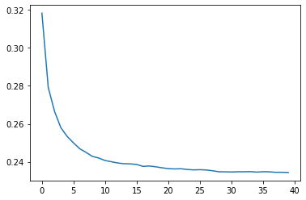

validation set is *worse* than the training set. Why?

- we might be overfitting
- the last two weeks of the auction data may have been different somehow

### Out of Bag Error (OOB error)

how can we check? we can use OOB predictions from the model and run rmse on the oob error.

```
r_mse(m.oob_prediction_, y)
```

```
0.211059
```

What is happening here?

OOB error gives you a sense of how much you are overfitting.

### Model interpretation

[source](https://github.com/fastai/fastbook/blob/master/09_tabular.ipynb)

For tabular data, model interpretation is particularly important. For a given model, the things we are most likely to be interested in are:

- How confident are we in our predictions using a particular row of data?
- For predicting with a particular row of data, what were the most important factors, and how did they influence that prediction?
- Which columns are the strongest predictors, which can we ignore?
- Which columns are effectively redundant with each other, for purposes of prediction?
- How do predictions vary, as we vary these columns?

```
preds_std = preds.std(0)
preds_std
```

```
array([0.24516726, 0.17149769, 0.12129906, ..., 0.1911843 , 0.16064838,
       0.16064838])
```

### Feature Important

```
def rf_feat_importance(m, df):
    return pd.DataFrame({'cols': df.columns, 'imp': m.feature_importances_}
                        ).sort_values('imp', ascending=False)
```

```
fi = rf_feat_importance(m, xs)

fi[:10]
```

|  | cols | imp |
| --- | --- | --- |
| 58 | YearMade | 0.175870 |
| 6 | ProductSize | 0.118317 |
| 30 | Coupler_System | 0.099115 |
| 7 | fiProductClassDesc | 0.071253 |
| 31 | Grouser_Tracks | 0.064081 |
| 55 | ModelID | 0.061831 |
| 50 | saleElapsed | 0.051997 |
| 32 | Hydraulics_Flow | 0.042906 |
| 3 | fiSecondaryDesc | 0.039384 |
| 1 | fiModelDesc | 0.031282 |

```
def plot_fi(fi):
    return fi.plot.barh('cols', 'imp', figsize=(12,8), legend=False)

plot_fi(fi[:30]);
```

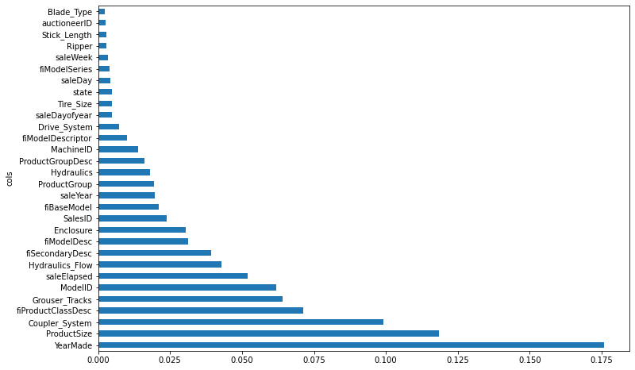

### Removing low-importance variables

```
to_keep = fi[fi.imp>0.005].cols
len(to_keep)
```

```
20
```

retrain model using only this subset of columns

```
xs_imp = xs[to_keep]
valid_xs_imp = valid_xs[to_keep]
```

```
m = rf(xs_imp, y)
```

```
m_rmse(m, xs_imp, y), m_rmse(m, valid_xs, valid_y)
```

[output not shown]

```
cluster_columns??
```

```
cluster_columns(xs_imp)
```

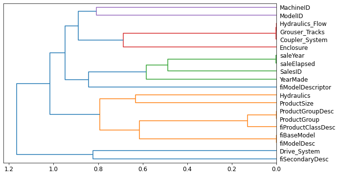

seems like we could remove some of the clustered columns.

Let's calculate a baseline using a sample of data

```
def get_oob(df):
    m = RandomForestRegressor(n_estimators=40, min_samples_leaf=15,
        max_samples=50000, max_features=0.5, n_jobs=-1, oob_score=True)
    m.fit(df, y)
    return m.oob_score_
```

```
get_oob(xs_imp)
```

```
0.8769414512037411
```

now remove redundant columns one at a time

```
{c:get_oob(xs_imp.drop(c, axis=1)) for c in (
    'saleYear', 'saleElapsed', 'ProductGroupDesc','ProductGroup',
    'fiModelDesc', 'fiBaseModel',
    'Hydraulics_Flow','Grouser_Tracks', 'Coupler_System')}
```

```
{'saleYear': 0.8754647378064608,
 'saleElapsed': 0.8723764211506366,
 'ProductGroupDesc': 0.8765810711892142,
 'ProductGroup': 0.8773280451665235,
 'fiModelDesc': 0.8758816619476205,
 'fiBaseModel': 0.8756967579434771,
 'Hydraulics_Flow': 0.8769591574648032,
 'Grouser_Tracks': 0.876871969234521,
 'Coupler_System': 0.8762546455208067}
```

not much change here so try dropping multiple variables

```
to_drop = ['saleYear', 'ProductGroupDesc', 'fiBaseModel', 'Grouser_Tracks']
get_oob(xs_imp.drop(to_drop, axis=1))
```

```
0.875680776530026
```

```
xs_final = xs_imp.drop(to_drop, axis=1)
valid_xs_final = valid_xs_imp.drop(to_drop, axis=1)
```

check rmse again to confirm accuracy hasn't really changed

```
m = rf(xs_final, y)
m_rmse(m, xs_final, y), m_rmse(m, valid_xs_final, valid_y)
```

```
(0.182544, 0.23238)
```

similar accuracy but less features!

### Partial Dependence

what is the relationship between variables

```
p = valid_xs_final['ProductSize'].value_counts(sort=False).plot.barh()
c = to.classes['ProductSize']
plt.yticks(range(len(c)),c);
```

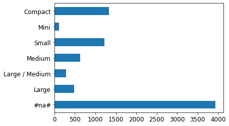

largest group is actual #na#

do the same for yearmade

```
ax = valid_xs_final['YearMade'].hist()
```

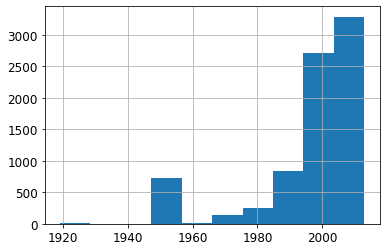

```
from sklearn.inspection import plot_partial_dependence

fig,ax = plt.subplots(figsize=(12, 4))
plot_partial_dependence(m, valid_xs_final, ['YearMade','ProductSize'],
                        grid_resolution=20, ax=ax);
```

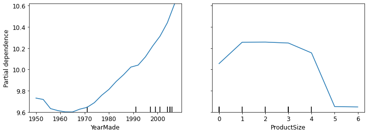

what is partial dependence telling us?

We want to look at how year affects the sale price, that is, all else being equal, what affect does year have on sale price

### Tree Interpreter

```
#!pip install treeinterpreter
#!pip install waterfallcharts
```

```
import warnings
warnings.simplefilter('ignore', FutureWarning)

from treeinterpreter import treeinterpreter
from waterfall_chart import plot as waterfall
```

```
row = valid_xs_final.iloc[:5]
```

```
prediction,bias,contributions = treeinterpreter.predict(m, row.values)
```

```
prediction[0], bias[0], contributions[0].sum()
```

```
(array([10.03875756]), 10.104200155980113, -0.06544259554720655)
```

```
waterfall(valid_xs_final.columns, contributions[0], threshold=0.08,
          rotation_value=45,formatting='{:,.3f}');
```

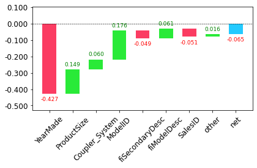

### The extrapolation problem

```
np.random.seed(42)
```

```
x_lin = torch.linspace(0,20, steps=40)
y_lin = x_lin + torch.randn_like(x_lin)
plt.scatter(x_lin, y_lin);
```

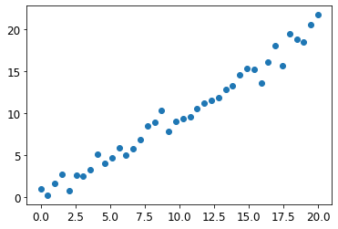

```
xs_lin = x_lin.unsqueeze(1)
x_lin.shape, xs_lin.shape
```

```
(torch.Size([40]), torch.Size([40, 1]))
```

you can do the same using `None`

```
x_lin[:,None].shape
```

```
torch.Size([40, 1])
```

```
m_lin = RandomForestRegressor().fit(x_lin[:30].reshape(-1, 1), y_lin[:30])
```

```
plt.scatter(x_lin, y_lin, 20)
plt.scatter(x_lin, m_lin.predict(xs_lin), color='red', alpha=0.5);
```

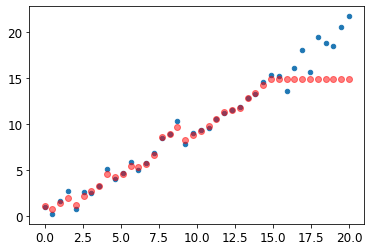

random forrext cannot extrapolate outside of the bounds of the training data

we need to make sure validation set does not contain out of domain data

test and training set may vary, how do we tell??

### Finding out of domain data

```
df_dom = pd.concat([xs_final, valid_xs_final])
is_valid = np.array([0]*len(xs_final) + [1]*len(valid_xs_final))

m = rf(df_dom, is_valid)
rf_feat_importance(m, df_dom)[:6]
```

|  | cols | imp |
| --- | --- | --- |
| 5 | saleElapsed | 0.915808 |
| 10 | SalesID | 0.069088 |
| 13 | MachineID | 0.011871 |
| 0 | YearMade | 0.000678 |
| 4 | ModelID | 0.000536 |
| 12 | Hydraulics | 0.000529 |

```
m = rf(xs_final, y)
print('orig', m_rmse(m, valid_xs_final, valid_y))

for c in ('SalesID','saleElapsed','MachineID'):
    m = rf(xs_final.drop(c,axis=1), y)
    print(c, m_rmse(m, valid_xs_final.drop(c,axis=1), valid_y))
```

```
orig 0.233484
SalesID 0.231357
saleElapsed 0.236643
MachineID 0.231104
```

```
time_vars = ['SalesID','MachineID']
xs_final_time = xs_final.drop(time_vars, axis=1)
valid_xs_time = valid_xs_final.drop(time_vars, axis=1)

m = rf(xs_final_time, y)
m_rmse(m, valid_xs_time, valid_y)
```

```
0.229127
```

```
xs['saleYear'].hist();
```

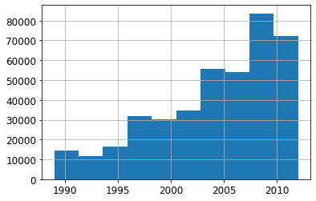

```
filt = xs['saleYear']>2004
xs_filt = xs_final_time[filt]
y_filt = y[filt]
```

```
m = rf(xs_filt, y_filt)
m_rmse(m, xs_filt, y_filt), m_rmse(m, valid_xs_time, valid_y)
```

```
(0.176904, 0.22864)
```

## Using a Neural Net

```
# load data
df_nn = pd.read_csv(dest/'TrainAndValid.csv', low_memory=False)

# set ProductSize as categorical
df_nn['ProductSize'] = df_nn['ProductSize'].astype('category')
df_nn['ProductSize'].cat.set_categories(sizes, ordered=True, inplace=True)

# take log of dependent variable
df_nn[dep_var] = np.log(df_nn[dep_var])

# do some date prep
df_nn = add_datepart(df_nn, 'saledate')
```

```
df_nn_final = df_nn[list(xs_final_time.columns) + [dep_var]]
```

```
cont_nn,cat_nn = cont_cat_split(df_nn_final, max_card=9000, dep_var=dep_var)
```

```
cont_nn.append('saleElapsed')
cat_nn.remove('saleElapsed')
```

```
df_nn['saleElapsed'] = df_nn['saleElapsed'].astype(int)
```

```
df_nn_final[cat_nn].nunique()
```

```
YearMade                73
ProductSize              6
Coupler_System           2
fiProductClassDesc      74
ModelID               5281
Hydraulics_Flow          3
fiSecondaryDesc        177
fiModelDesc           5059
Enclosure                6
ProductGroup             6
Hydraulics              12
fiModelDescriptor      140
Drive_System             4
dtype: int64
```

```
xs_filt2 = xs_filt.drop('fiModelDescriptor', axis=1)
valid_xs_time2 = valid_xs_time.drop('fiModelDescriptor', axis=1)
m2 = rf(xs_filt2, y_filt)
m_rmse(m2, xs_filt2, y_filt), m_rmse(m2, valid_xs_time2, valid_y)
```

```
(0.178922, 0.230357)
```

```
cat_nn.remove('fiModelDescriptor')
```

```
df_nn_final['saleElapsed'].astype('int64', copy=False)

df_nn_final.dtypes
```

```
YearMade                 int64
ProductSize           category
Coupler_System          object
fiProductClassDesc      object
ModelID                  int64
saleElapsed              int64
Hydraulics_Flow         object
fiSecondaryDesc         object
fiModelDesc             object
Enclosure               object
ProductGroup            object
Hydraulics              object
fiModelDescriptor       object
Drive_System            object
SalePrice              float64
dtype: object
```

### Normalize

`Normalize` subtracts the mean, then divides by the standard deviation. We didn't need this for a decision tree because we were only performing binary splits. However, we do need to normalize for neaural nets because we don't want things with crazy distributions.

```
procs_nn = [Categorify, FillMissing, Normalize]
to_nn = TabularPandas(df=df_nn_final,
                      procs=procs_nn,
                      cat_names=cat_nn,
                      cont_names=cont_nn,
                      splits=splits,
                      y_names=dep_var)
```

```
dls = to_nn.dataloaders(1024)
```

This is a regression model so we want to set our `y_range` based on the min and max of the dependent variable.

```
y = to_nn.train.y
y.min(),y.max()
```

```
(8.465899, 11.863583)
```

```
learn = tabular_learner(dls, y_range=(8,12), layers=[500,250],
                        n_out=1, loss_func=F.mse_loss)
```

```
learn.lr_find()
```

```
SuggestedLRs(lr_min=0.003981071710586548, lr_steep=0.00019054606673307717)
```

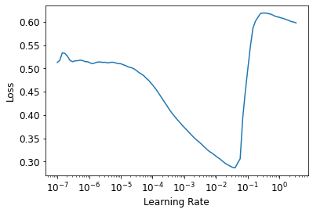

```
learn.fit_one_cycle(5, 1e-2)
```

| epoch | train_loss | valid_loss | time |
| --- | --- | --- | --- |
| 0 | 0.069223 | 0.062953 | 00:11 |
| 1 | 0.056285 | 0.055872 | 00:13 |
| 2 | 0.048484 | 0.055052 | 00:12 |
| 3 | 0.043525 | 0.051425 | 00:12 |
| 4 | 0.040454 | 0.051055 | 00:11 |

```
preds,targs = learn.get_preds()
r_mse(preds,targs)
```

```
0.225954
```

### Summary

**Random Forests** are easy to train, resillient, don't require much pre-processing, train quickly and don't overfit. They can be less accurate than a neural net and can take longer at inference time to evaluate the trees.

**Neural Nets** are probably the fiddliest models to implement and set up but can give slightly better results.